# Shipwrecks Network in the Mediterranean Basin

Antonio Rivero Ostoic

CEDHAR, Aarhus University

jaro@cas.au.dk

23 June 2022

This post concerns the database from Strauss on Roman shipwrecks network:

Strauss, J. (2013). *Shipwrecks Database*. Version 1.0. Accessed (07-12-2021) from oxrep.classics.ox.ac.uk/databases/shipwrecks_database/

Built from Parker, A.J. *Ancient Shipwrecks of the Mediterranean and the Roman Provinces* (Oxford: BAR International Series 580, 1992)

## Shipwrecks Database

Andrew Wilson coordinates a catalogue of all known ancient wrecks in the Mediterranean up to 1500 AD where there is the database from Julia Strauss’s PhD thesis *Roman Cargoes: Underwater Evidence from the East* (London 2007).

#### Requirements

Install and load `R` packages to run the code snippets.

```r
devtools::install_github("mplex/cedhar", subdir="pkg/sdam") # install beta v0.9.3
library("sdam") # v0.9.2 or higher
library("readxl") # read MS Excel sheets
library("networkD3") # plot interactive graphs
library("multiplex") # v2.9.8 or higher
library("multigraph") # plot valued directed graphs
```

```r
# check version
packageVersion("sdam")
```

```
[1] '0.9.3'
```

#### Retrieving the Data

The Shipwrecks Database is distributed as a `ZIP` *filesystem* that needs a temporal file where to download it. The workflow below gives the steps in `R` with credits to [this discussion](https://stackoverflow.com/questions/3053833/).

```r
temp <- tempfile()
download.file("http://oxrep.classics.ox.ac.uk/docs/StraussShipwrecks.zip", temp)
```

Next, we make the connection with the temporal file and unzip it with the `"utils"` package into object `con`, and because `StraussShipwrecks` is an MS Excel file with different sheets, we use package `"readxl"` to recursively read the excel sheets.

```r
# connect temporal file and unzip excel file
con <- utils::unzip(temp, "StraussShipwrecks.xlsx")
```

```r
# recursively read Excel sheets
allsheets <- sapply(readxl::excel_sheets(con), simplify=FALSE, USE.NAMES=TRUE,
            function(z) readxl::read_excel(con, sheet = z))
```

Before continuing with the analysis, however, we need to close the connections and remove unused files.

```r
# close connection and garbage collection
CatchupPause <- function(Secs) {
 Sys.sleep(Secs)
 closeAllConnections()
 gc()
 }
# close also with temporal file
unlink(temp)
```

#### Shipwrecks Dataset

We start by looking at this database with the `"base"` `summary()` function.

```r
# content in the excel sheets
summary(allsheets)
```

```
           Length Class  Mode
Shipwrecks 35     tbl_df list
Amphorae    5     tbl_df list
```

Where we can see that actually the database contains two datasets, `Shipwrecks` and `Amphorae`, which are components having 35 and 5 variables, respectively. Class for each dataset is `tbl_df` since package `"readxl"` stores these two data frames with a *tibble* flavour.

The first component of the database has the shipwrecks dataset recorded in `sw` where the variables are listed in the column names.

```r
# shipwrecks dataset and class object
sw <- allsheets$Shipwrecks
class(sw)
```

```
[1] "tbl_df"     "tbl"        "data.frame"
```

```r
# variables in dataset
colnames(sw)
```

```
 [1] "Wreck ID"                "Strauss ID"              "Name"
 [4] "Parker Number"           "Sea area"                "Country"
 [7] "Region"                  "Latitude"                "Longitude"
[10] "Min depth"               "Max depth"               "Depth"
[13] "Period"                  "Dating"                  "Earliest date"
[16] "Latest date"             "Date range"              "Mid point of date range"
[19] "Probability"             "Place of origin"         "Place of destination"
[22] "Reference"               "Comments"                "Amphorae"
[25] "Marble"                  "Columns etc"             "Sarcophagi"
[28] "Blocks"                  "Marble type"             "Other cargo"
[31] "Hull remains"            "Shipboard paraphernalia" "Ship equipment"
[34] "Estimated tonnage"       "Amphora type"
```

### Sea Areas

The shipwrecks dataset has geographical information to produce networks of relations with possible trajectories of the Roman ships. These variables are the `Sea area` of the shipwreck together with the network data in `Place of origin` and `Place of destination` that are columns 5, 20 and 21 in object `sw`.

```r
# geographic variables
sw[ ,c(5,20:21)]
```

```
# A tibble: 1,784 x 3
   `Sea area`            `Place of origin` `Place of destination`
   <chr>                 <chr>             <chr>
 1 Adriatic              Egypt             Northern Italy
 2 Adriatic              Cos               Northern Italy
 3 Adriatic              Rhodes            Northern Italy
 4 Adriatic              Aegean            Northern Italy
 5 Adriatic              <NA>              <NA>
 6 Adriatic              Rhodes            northern Italy
 7 Adriatic              Aegean            Northern Italy
 8 Western Mediterranean Aegean via Cosa   France
 9 Tyrrhenian Sea        Aegean.           Rome
10 Adriatic              Aegean            Northern Italy
# ... with 1,774 more rows
```

#### Cleaning Data

There are, however, some record entries with extra characters like question marks, spaces, lower/upper cases, etc. that need “cleaning” for a better analysis.

```r
# four entries to clean
sw[c(6,9,35,130), c(5,20:21)]
```

```
# A tibble: 4 x 3
  `Sea area`            `Place of origin` `Place of destination`
  <chr>                 <chr>             <chr>
1 Adriatic              Rhodes            northern Italy
2 Tyrrhenian Sea        Aegean.           Rome
3 Aegean                Cos?              Black Sea?
4 Eastern Mediterranean Tripolitania (?)  Brega, for trans shipment (?)
```

The internal function `cln()` in `"sdam"` removes special characters and capitalizes words to uniform the data. Below are four cases in the shipwreck dataset where variables `Sea area`, `Place of origin`, and `Place of destination` are to clean.

```r
# default clean
sdam::cln(sw[c(6,9,35,130), c(5,20:21)])
```

```
               Sea area Place of origin         Place of destination
1              Adriatic          Rhodes               northern Italy
2        Tyrrhenian Sea         Aegean.                         Rome
3                Aegean             Cos                    Black Sea
4 Eastern Mediterranean Tripolitania () Brega, for trans shipment ()
```

```r
# include specific characters
cln(sw[c(6,9,35,130), c(5,20:21)], what=c("(",")"))
```

```
               Sea area Place of origin       Place of destination
1              Adriatic          Rhodes             northern Italy
2        Tyrrhenian Sea         Aegean.                       Rome
3                Aegean             Cos                  Black Sea
4 Eastern Mediterranean   Tripolitania  Brega, for trans shipment
```

```r
# raise level for dots and spaces at the end
cln(sw[c(6,9,35,130), c(5,20:21)], level=2, what=c("(",")"))
```

```
               Sea area Place of origin      Place of destination
1              Adriatic          Rhodes            northern Italy
2        Tyrrhenian Sea          Aegean                      Rome
3                Aegean             Cos                 Black Sea
4 Eastern Mediterranean    Tripolitania Brega, for trans shipment
```

```r
# also capitalize words
cln(sw[c(6,9,35,130), c(5,20:21)], level=2, what=c("(",")"), case=1)
```

```
               Sea area Place of origin      Place of destination
1              Adriatic          Rhodes            Northern Italy
2        Tyrrhenian Sea          Aegean                      Rome
3                Aegean             Cos                 Black Sea
4 Eastern Mediterranean    Tripolitania Brega, For Trans Shipment
```

The first option removes only characters `?*+`, and the second one removes also parenthesis. The command with a raised `"level"` removes also unnecessary spaces and dots at the end of each record, and `1` in `"case"` implies capitalization of just the first letter in each word.

Other entries, however, may have typo errors that need replacement:

```r
# four entries for replacement
sw[c(632,1423,1496,1777), c(5,20:21)]
```

```
# A tibble: 4 x 3
  `Sea area`            `Place of origin` `Place of destination`
  <chr>                 <chr>             <chr>
1 Western Mediterranean Lllobregat, Spain <NA>
2 Western Mediterranean Aegean            Marseillles
3 Western Mediterranean Marseilles        <NA>
4 <NA>                  Islamic Mahgreb?  <NA>
```

A list of replacements for places in `sw` is recorded as a data frame in `rptxt` having two columns, one for “text to replace” and the other column for “text that replace them”.

```r
# replace text for places
rptxt <- read.table(header=FALSE, text="
  Lll Ll
  lll ll
  Marseilles Marseille
  Mahgreb Maghreb
  ")
```

Cleaning and replacement are combined in `cln()` for the entries in the shipwreck dataset in `sw`.

```r
# entries example cleaned
cln(sw[c(6,9,35,130,632,1423,1496,1777), c(5,20:21)], level=2, what=c("(",")"), case=1,
    repl=rptxt)
```

```
               Sea area  Place of origin      Place of destination
1              Adriatic           Rhodes            Northern Italy
2        Tyrrhenian Sea           Aegean                      Rome
3                Aegean              Cos                 Black Sea
4 Eastern Mediterranean     Tripolitania Brega, For Trans Shipment
5 Western Mediterranean Llobregat, Spain                      <NA>
6 Western Mediterranean           Aegean                 Marseille
7 Western Mediterranean        Marseille                      <NA>
8                  <NA>  Islamic Maghreb                      <NA>
```

### Network Relations

The places of origin and destination recorded in the Strauss shipwrecks dataset allows us producing a network representation of the possible trajectories of the Roman ships, and this information constitutes one kind of relation in a broader transportation system.

#### Edge List and Adjacency Matrix

In order to produce the network, we create first an edge list object called `edgel` with the two network variables in `sw` cleaned with the `cln()` options.

```r
# edge list cleaned and NA entries removed
edgel <- cln(sw[, 20:21], level=2, what=c("(",")"), case=1, na.rm=FALSE, repl=rptxt)
```

```r
# head and tail of edge list
rbind(head(edgel), tail(edgel))
```

```
     Place of origin Place of destination
1              Egypt       Northern Italy
2                Cos       Northern Italy
3             Rhodes       Northern Italy
4             Aegean       Northern Italy
5               <NA>                 <NA>
6             Rhodes       Northern Italy
1779         Baetica                 <NA>
1780            <NA>                 <NA>
1781            <NA>                 <NA>
1782        Campania                 <NA>
1783            <NA>                 <NA>
1784            <NA>                 <NA>
```

```r
# handle <NA> before transforming into matrix (R v4.0+)
edgel$`Place of origin`[is.na(edgel$`Place of origin`)] <- "NA"
edgel$`Place of destination`[is.na(edgel$`Place of destination`)] <- "NA"
```

Uses function `transf()` from `"multiplex"` to transform the edge list into the *adjacency matrix* of the network in array `mat`.

```r
# construct matrix from edge list assuming one relation
mat <- multiplex::transf(edgel, type="toarray")
```

```r
# matrix size of network
dim(mat)
```

```
[1] 162 162
```

#### Graph Representation of Shipwreck Routes

We plot the Roman Shipwrecks network as a directed graph using a force-directed layout algorithm as implemented in the `R` package `"multigraph"`. The graph plotted below has labels of four hubs in the Roman shipwrecks network and different options that allows seeing the other components of the network.

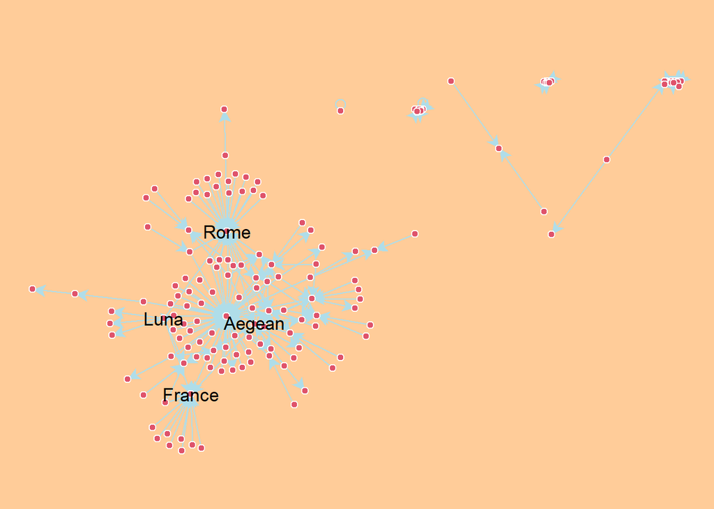

Graph of Shipwrecks Network with Four Labeled Hubs.

```r
# plot graph with a scope and selected labels
scp <- list(pos=0, col=66, ecol="#AFDDE9", vcol0="white", fsize=11, bg="#FFCC99")
multigraph::multigraph(mat, scope=scp, loops=TRUE, layout="force", seed=123,
                       sel=c("Aegean","France","Luna","Rome") )
```

#### Plotting with `"networkD3"`

`"networkD3"` is an `R` package popular for producing Sankey diagrams, and which uses the capabilities of `"htmlwidgets"` package. It has function `simpleNetwork()` to be able to plot networks as *‘D3 JavaScript’ network* graph allowing interactivity through a web browser. Plotting the sea regions in the Roman Shipwrecks network with this function, however, needs a data frame class object with the edge list as the input network.

To convert the ties recorded in matrix `mat` into an edge list format, we use `transf()` again but now with the `"toedgel"` option in the `'type'` argument where `edgel` carries the edge list. However, some labels in `mat` have names separated by a comma followed by space, which is the default separator `'sep'` of `transf()` function. This is the case, for example, of `"Adriatic Via Africa, Spain, France"`, which means that we need to specify a tab separator in `'sep'` (or another value) in order to avoid breaking labels in the edge list.

```r
# some places in adjacency matrix
attr(mat, "dimnames")[[1]][60:62]
```

```
[1] "Cos, Crete, Italy"   "Cos, Rhodes"         "Cos, Rhodes, Athens"
```

```r
# edge list with a tabulator separator
elmat <- transf(mat, type="toedgel", sep="\t")
```

First records in edge list where columns `s`, `r`, and `t` are for senders, receivers, and network ties in the data frame.

```r
# first five entries
head(elmat)
```

```
                                   s             r t
1         Adriatic-Brindisi-Campania   Gaul, Spain 1
2 Adriatic Via Africa, Spain, France          Pisa 1
3                           Adriatic        Aegean 1
4                           Adriatic        Aegean 1
5                           Adriatic    Alexandria 1
6                           Adriatic Cyprus/Levant 1
```

With the edge list as `elmat`, we can plot the sea regions of the Roman shipwrecks network with `simpleNetwork()` from `"networkD3"` that has a `'zoom'` and other options to see more easily the graph structure with a Web browser.

```r
# zoom into a simple undirected network
networkD3::simpleNetwork(elmat, fontFamily="sans-serif", opacity=1, zoom=TRUE)
```

#### Network Components

Function `comps()` from package `"multiplex"` provides the network components and isolates with the relations recorded in the adjacency matrix in `mat`.

```r
# find network components
multiplex::comps(mat)
```

```
$com
$com[[1]]
[1] "a Palace In The Aegean"     "Syria/Palestine Via Ugarit"

$com[[2]]
  [1] "Aegean Tripolitania Italy"       "Italy"
  [3] "Italy Via Crete And Rhodes"      "Levant"
  [5] "Llobregat And Maresme, Spain"    "Llobregat, Spain"
  [7] "Luna"                            "Lusitania"
  [9] "Lusitania-Baetica"               "Maresme, Spain"
 [11] "Aegean Via Cosa"                 "Marseille"
 [13] "Mesembria"                       "NA"
 [15] "Narbonne, France"                "Neapolis Nabeul North Africa"
 [17] "Near East"                       "North Africa"
 [19] "Northeast Mediterranean"         "Northern Italy"
 [21] "Aegean Via Southern Italy"       "Odessos"
 [23] "Palestine And Elsewhere"         "Palestine Cilicia, Aegean"
 [25] "Palestine/Rhodes"                "Pamphylia"
 [27] "Paros"                           "Pergamum"
 [29] "Phoenicia"                       "Aegean, Italy"
 [31] "Proconnesus"                     "Rhodes"
 [33] "Rhodes, Cos"                     "Rome"
 [35] "Rome/France/Spain"               "Samos"
 [37] "Sardinia"                        "Sicily"
 [39] "Aegean/Africa"                   "Sicily/Rome"
 [41] "South Coast Black Sea"           "South Of France"
 [43] "South West France Inland France" "Southeast Aegean"
 [45] "Southern Cyprus"                 "Southern Italy"
 [47] "Spain"                           "Aegean/N. Africa/Propontis"
 [49] "Spain, Aegean, Adriatic"         "Syria"
 [51] "Tarraconensis"                   "Teos, Naxos, Rome"
 [53] "Tera"                            "Thasos"
 [55] "Thasos/Asia Minor"               "Africa"
 [57] "Thessaly, Proconnesus"           "Thessaly/Euboea"
 [59] "Alex/Pergamum/Aegean"            "Alexandria"
 [61] "Anhialo"                         "Adriatic"
 [63] "Aquileia"                        "Asia"
 [65] "Asia Minor"                      "Assos"
 [67] "Athens"                          "Athens Via Delos"
 [69] "Baetica"                         "Baetica-Narbonne"
```

[output cut: 66 more lines]

```
$com[[15]]
[1] "Athens, Then Mende, Then Peparethos" "Ikos"

$com[[16]]
[1] "Eastern Cilicia" "Aegean Rome"

$com[[17]]
[1] "Egypt Luna"    "France, Spain"

$com[[18]]
[1] "Egypt W. Med" "Gaul"


$isol
[1] "Southern Levant Or Cyprus"
```

Notice that according to the output there is an isolated entity in the network. However, this is another component in the Roman Shipwrecks network having a self-relationship where `NA` stands for the missing information.

```r
# last four bundles
require("magrittr")
mat %>%
  multiplex::bundles(loops=TRUE) %>%
  multiplex::summaryBundles() %>%
  tail(4)
```

```
                                                          Bundles
Loop1                                       o{R} (Cyprus, Cyprus)
Loop2                                         o{R} (Italy, Italy)
Loop3                                               o{R} (NA, NA)
Loop4 o{R} (Southern Levant Or Cyprus, Southern Levant Or Cyprus)
```

Part of the exploratory network analysis is to look at the dyadic relations in the system, particularly if is directed like the Roman Shipwrecks network. The two functions from `"multiplex"` used above serve to find the different bundle patterns occurring in the network.

##### Largest Component

We focus on the largest component of the network, which is the second constituent in the output of `comps()` above. By selecting this component with argument `'sel'` in function `rel.sys()`, we obtain the adjacency matrix of this section as an array `'type'` object that is recorded in `matc` with has 125 nodes.

```r
# construct adjacency matrix of largest component
matc <- multiplex::rel.sys(mat, type="toarray", sel=comps(mat)$com[[2]])
```

```r
# matrix size of component
dim(matc)
```

```
[1] 125 125
```

There is also bundle patterns that are self-relationships.

```r
require("magrittr")
matc %>%
  bundles(loops=TRUE) %>%
  summaryBundles() %>%
  tail(2)
```

```
                  Bundles
Loop1 o{R} (Italy, Italy)
Loop2       o{R} (NA, NA)
```

Locations and their connections are easier to see when plotting the largest component of sea regions in the Shipwrecks network. With `"multigraph"`:

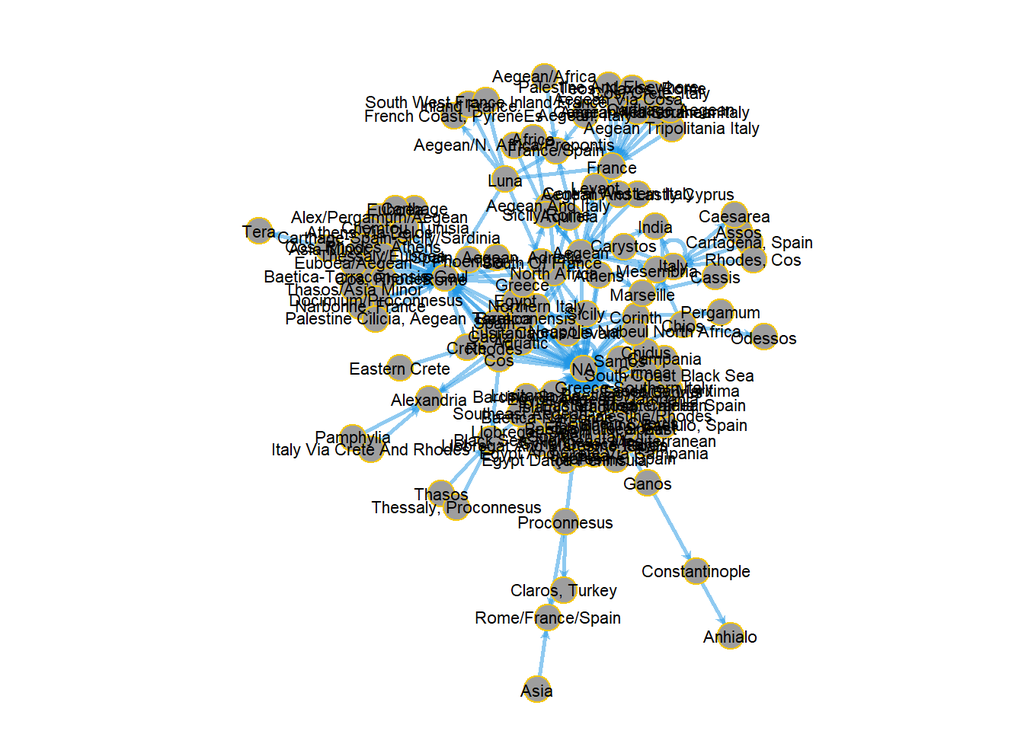

Directed Graph of Largest Component in Roman Shipwrecks Network.

```r
# graph of largest component with loops and node labels
multigraph(matc, loops=TRUE, layout="force", seed=6, cex=2.5, lwd=2.5, col=8, vcol0=7, ecol=4, pos=0, fsize=7, alpha=c(1,.5))
```

And plotting largest component of sea regions with `"networkD3"`:

```r
# interactive graph without zoom
simpleNetwork(transf(matc,type="toedgel",sep="\t"), fontFamily="sans-serif", opacity=1)
```

## Seas in the Mediterranean Basin

The two variables in edge list `edgel`, which are `Place of origin` and `Place of destination`, have all network locations that belong to a certain sea or region in the Mediterranean Basin or neighbouring waters. To simplify the network structure, we need to group the different places in the two network variables, and one could use for this the `Sea area` variable in `sw`. However, this variable corresponds to the shipwreck locations, which in many cases are far from the origin and destination of the ship.

The following characters serve to discern clusters of origin and destination places within Strauss Roman Shipwrecks network where most sea names are in D. Hessong cartographical map (2001) deposited in an [online repository for Diplomacy information](http://www.dipwiki.com/images/5/5c/AncientMed9_Names.gif).

- **A** or **Æ**: Aegean, including Minoan Sea
- **D**: Adriatic Sea
- **I**: Ionian Sea, including Ausonian Sean and Messenian Sea
- **T**: Tyrrhenian Sea
- **B**: Baetica, including Alboran/Iberian Sea
- **L**: Ligurian Sea, including Baleares
- **E**: East, from Cilician Strait through Levante Basin
- **F**: Africa, including Libyan Sea and Cyrene
- **P**: Punic Sea, including Berber Sea
- **C**: Black Sea
- **G**: Gaul
- **X**: India

Because some locations entries in this dataset are vague, the clustering information for the places of origin and destination for the reduction of the network result ambiguous with entries having more than one letter.

The assignation of *Sea Regions* to the places of origin and destination was made by hand and are recorded in a tabular separated table in file `ShipwreckSeas.txt`. To load this file into object `ss` we need to specify the tabulator separator of the data that has a header in this case.

```r
# read file with Mediterranean sea regions per place
ss <- read.table(file="ShipwreckSeas.txt", header=TRUE, sep="\t")
```

An excerpt of `ss` given below illustrates the location ambiguity in the data. For instance, `Aegean And Italy` in entry 8 imply three possible region seas that are Aegean, Ionian, and Adriatic; however, `Aegean Rome` in entry 10 implies the west coast of the Italian peninsula. In this case, the sea region corresponds to the Tyrrhenian Sea rather than the east coast facing the Adriatic.

```r
# excerpt with 9 sea regions
ss[8:16,]
```

```
                        PLACE  CODE
8            Aegean And Italy A,D,I
9    Aegean And Lastly Cyprus   A,E
10                Aegean Rome A,T,I
11  Aegean Tripolitania Italy A,D,I
12            Aegean Via Cosa     A
13  Aegean Via Southern Italy   A,I
14              Aegean, Italy A,D,I
15              Aegean/Africa   A,F
16 Aegean/N. Africa/Propontis   A,F
```

### Network Reduction

A clustering information serves to reduce the network into related sets of equivalent places in the system.

```r
# matching sea regions to the edge list
ss[c(head(match(edgel[,1], ss$PLACE),3), tail(match(edgel[,1], ss$PLACE),3)),]
```

```
        PLACE CODE
73      Egypt    E
60        Cos    A
137    Rhodes    A
45   Campania    T
NA       <NA> <NA>
NA.1     <NA> <NA>
```

However, missing data in `ss` should be recorded as `"NA"` for future transformations.

```r
# handle <NA> for transformation (R v4.0+)
ss$PLACE[is.na(ss$PLACE)] <- "NA"
ss$CODE[is.na(ss$CODE)] <- "NA"
```

Create a new edge list `edgelc` as data frame with sea region codes in `ss`, which are in new columns `from` and `to`.

```r
# edge list with codes
edgelc <- cbind(edgel, from=ss[match(edgel[,1], ss$PLACE),]$CODE,
                       to=ss[match(edgel[,2], ss$PLACE),]$CODE)
```

```r
# handle <NA> before transforming into matrix (R v4.0+)
edgelc$from[is.na(edgelc$from)] <- "NA"
edgelc$to[is.na(edgelc$to)] <- "NA"
```

```r
# look at last entries
tail(edgelc)
```

```
     Place of origin Place of destination from to
1779         Baetica                   NA    B NA
1780              NA                   NA   NA NA
1781              NA                   NA   NA NA
1782        Campania                   NA    T NA
1783              NA                   NA   NA NA
1784              NA                   NA   NA NA
```

Unique labels in origin and destination of sea regions are

```r
# from sea region
unique(edgelc$from)
```

```
 [1] E       A       NA      A,F     E,A     C       T,I,D   D       A,I     I       A,D,I   A,E
[13] P       M       T       L       B,L,A,D A,I,T   P,I,A   F       B,L,I   B,L     B       I,F
[25] L,D     I,T     T,P     A,P
35 Levels: A A,D,I A,E A,F A,I A,I,T A,P A,T,I B B,L B,L,A,D B,L,G B,L,I C D E E,A F G I ... NA
```

```r
# to sea region
unique(edgelc$to)
```

```
 [1] L,D   NA    L,G   T     I,T   A     A,T,I C     T,I,D E     F     X     L     B     I,P   G
[17] T,L   D     B,L,G
35 Levels: A A,D,I A,E A,F A,I A,I,T A,P A,T,I B B,L B,L,A,D B,L,G B,L,I C D E E,A F G I ... NA
```

#### Sea Regions Origin and Destination

The adjacency matrix of letters in `mat` comes from columns `from` and `to` in edge list `edgelc` and are located in column positions 3 and 4. We extract these two columns to produce a matrix `matr` with ties in sea regions to plot the multigraph of the reduced structure later on.

```r
# construct sea regions matrix
matr <- transf(edgelc[,3:4], type="toarray")
```

```r
# matrix size of sea regions
dim(matr)
```

```
[1] 35 35
```

```r
# scope valued graph characteristics
scpv <- list(valued=TRUE, cex=2.5, fsize=8, pos=0, ecol=4, col=8, vcol0=7)
```

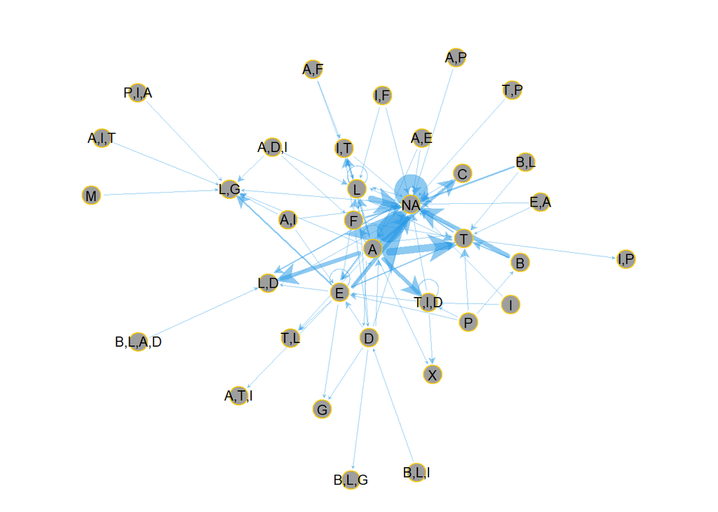

Valued Graph of Sea Regions in the Roman Shipwrecks Network.

```r
# force-directed with random seed
multigraph(matr, loops=TRUE, scope=scpv, layout="force", seed=18, lscl=.09, alpha=c(1,.5))
```

To plot the reduced structure with `simpleNetwork()` from `"networkD3"` on an edge list from its adjacency matrix.

```r
# interactive graph
simpleNetwork(transf(matr, type="toedgel"), fontFamily="sans-serif", opacity=1)
```

### Aggregation of Sea Regions in the Mediterranean Basin

Further aggregation of the Sea Regions in the Mediterranean Basin is possible by grouping them where a number is given to geographical regions in the Mediterranean Basin:

- **1**: West
- **2**: East
- **21**: East-West
- **12**: West-East (also when West and East are tied)
- **3**: Far East
- **0**: `NA`

First, we take from `ss` the sea regions codes in component `CODE` and group them by hand.

```r
# sea region names
name <- unique(as.vector(ss$CODE))
# sea region groups
group <- c(0,2,2,2,2,21,2,2,2,2,2,1,2,1,1,1,1,12,2,1,1,1,3,21,12,21,12,1,1,21,2,12,12,1,21)
```

```r
# sea regions names with their goups
require("magrittr")
  rbind(name, group) %>%
  as.table()
```

```
      A  B C D     E   F     G   H   I J K L M N O   P Q R     S   T   U V W X   Y     Z   A1  B1
name  NA A D A,D,I A,E A,T,I A,I A,F F E C L I B B,L T P P,I,A E,A L,G G M X A,P T,I,D I,F L,D T,L
group 0  2 2 2     2   21    2   2   2 2 2 1 2 1 1   1 1 12    2   1   1 1 3 21  12    21  12  1
      C1  D1  E1  F1    G1      H1    I1
name  T,P I,T I,P B,L,I B,L,A,D B,L,G A,I,T
group 1   21  2   12    12      1     21
```

However, better record the grouping information of sea regions as a data frame in `ssg`.

```r
# sea regions by group
ssg <- as.data.frame(cbind(name, group))
```

```r
# last fourteen sea regions with groups
tail(ssg,14)
```

```
      name group
22       M     1
23       X     3
24     A,P    21
25   T,I,D    12
26     I,F    21
27     L,D    12
28     T,L     1
29     T,P     1
30     I,T    21
31     I,P     2
32   B,L,I    12
33 B,L,A,D    12
34   B,L,G     1
35   A,I,T    21
```

By looking at part of the data, we evidence for instance that

- · Mediterranean sea or `M` is coded `1` for “West”
- · Sea region `X` that corresponds to “Far-East” is coded as `3`
- · Aegean/Punic seas `A,P` are `21` for “East-West”
- · Gaul is “West”

#### Aggregated Edge List and Adjacency Matrix

Create edge list `edgelcg` with component groups by marching the sea region in `ssg` with both `Place of origin` and `Place of destination` recorded in components `from` and `to` in `edgelc`.

```r
# edgelist component groups
edgelcg <- cbind(edgelc, fra=ssg[match(edgelc$from, ssg$name), ]$group,
                         til=ssg[match(edgelc$to, ssg$name), ]$group)
```

```r
# handle <NA> before transforming into matrix (REQUIRES: R v4.0+)
edgelcg$fra[is.na(edgelcg$fra)] <- 0
edgelcg$til[is.na(edgelcg$til)] <- 0
```

```r
# last five entries
tail(edgelcg)
```

```
     Place of origin Place of destination from to fra til
1779         Baetica                   NA    B NA   1   0
1780              NA                   NA   NA NA   0   0
1781              NA                   NA   NA NA   0   0
1782        Campania                   NA    T NA   1   0
1783              NA                   NA   NA NA   0   0
1784              NA                   NA   NA NA   0   0
```

The adjacency matrix for groups of sea regions comes from the last two columns of the edgelist component groups.

```r
# construct matrix from edgelist component groups
ssgmat <- transf(edgelcg[,5:6], type="toarray")
```

```
      0  1 12  2 21 3
0  1465  2  4  1  0 0
1    45 17  1  4  1 0
12    4  1  2  2  0 2
2    93 57 27 38  9 1
21    6  2  0  0  0 0
3     0  0  0  0  0 0
```

Then plot as a valued graph and customized labels.

```r
# region labels
lbs <- c("NA","West","West/East","East","East/West","Out")
# scope valued
scpv <- list(valued=TRUE, cex=5, pos=0, ecol="blue", col="gray", vcol0="white")
```

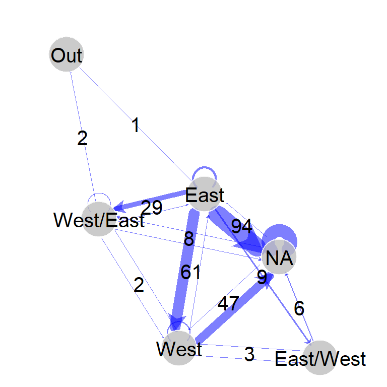

Groups of Sea Regions in the Roman Shipwrecks Network.

```r
# plot with customized scope, labels and loop scale
multigraph(ssgmat, loops=TRUE, layout="force", seed=11, scope=scpv, lbs=lbs, lscl=.15, alpha=c(.8,.5))
```

#### Graph and Cartographical Map

Alternatively, it is possible to create customized coordinates for plotting the graph, which is based on a force directed layout algorithm.

```r
# Mediterranean coordinated system (six-class)
medcd <- read.table(header=FALSE, text="
  0.3499740 0.52921756
  0.0000000 0.30046916
  0.2333714 0.11265614
  0.7252469 0.30461617
  0.5221496 0.09305772
  1.0000000 0.00000000  ")
```

This coordinated system allows plotting the graph of the shipwrecks networks on a cartographical map of the Mediterranean sea as recorded in a `"sdam"` dataset used by function `plot.map()`.

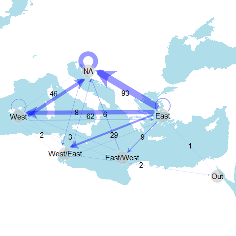

Sea Regions in the Mediterranean Basin.

```r
# cartographical map and graph with coordinated system and loop scale
sdam::plot.map(type="med", new=TRUE)
multigraph(ssgmat, coord=medcd, scope=scpv, values=TRUE, loops=TRUE, lbs=lbs, lscl=.15, new=TRUE)
```

In this case, the arcs in the graph include the total amount of shipwrecks found among the aggregated sea regions in the Mediterranean Basin, except in the loops. We can see, for instance, that most of the traffic of the shipwrekcs with cargo were between `East` and `West` if not `NA` accroding to the applied aggregation criteria.

## Timespans of Existence and Relative Dating

A temporal span or *timespan* of existence $\tau$ is a temporal stage or time block in a range of time $\varOmega$ of the distance between two boundaries of existence, a “limit before which” and a “limit after which”.

Time blocks $a$ and $b$ are finite and they stand for the “before-” and “after which” $\tau$, respectively, which implies that any timespan is natural ordered related between time blocks $a$ and $b$.

$$a \leq \tau \leq b$$

When the three temporal stages in percentages are known, which means they are finite, each time block is calculated as 100 minus the sum of the other stages

$$\begin{align*}
a=100-(b+\tau)\phantom{.} \\
\tau=100-(a+b)\phantom{.} \\
b=100-(a+\tau).
\end{align*}$$

This arrangement of time blocks in the order of their occurrence constitutes a chronology with a timeline that looks like:

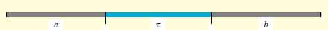

### Time Variables in Shipwreck Data

There are variables in the Roman shipwrecks dataset related to time and dating. For instance, variables `'Earliest date'` and `'Latest date'` serve to delimit the timespans of existence of the shipwreck record. Other two time related variables having data are `'Period'` and `'Dating'`, while variables `"Date range"`, `"Mid point of date range"`, and `"Probability"` do not contain any data in `sw`. However, these two variables can be calculated from the available timespans of existence.

```r
# time related variables
colnames(sw)[13:19]
```

```
[1] "Period"                  "Dating"                  "Earliest date"
[4] "Latest date"             "Date range"              "Mid point of date range"
[7] "Probability"
```

#### Plotting `sw` Dates

Use function `plot.dates()` from package `"sdam"` to plot the timespans of existence of the shipwrecks dataset with the delimiting variables of the timespan as `taq` and `tpq`.

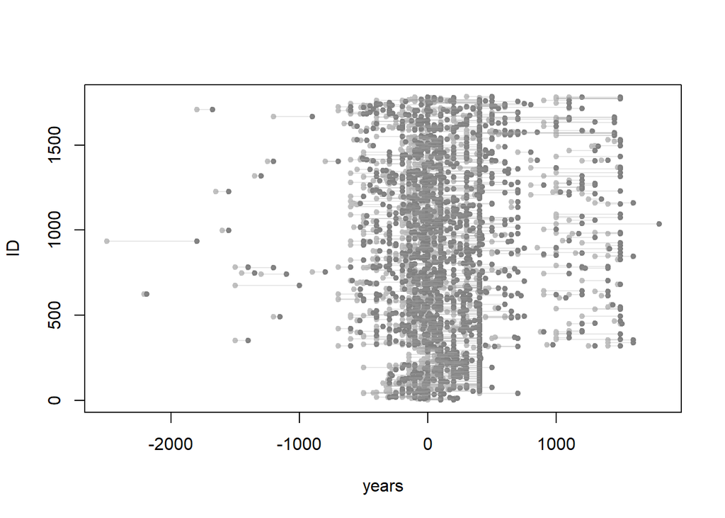

Shipwrecks Timespans of Existence

```r
# plot shipwrecks timespans
sdam::plot.dates(sw, taq="Earliest date", tpq="Latest date")
```

Alternatively, plot with `plot.dates()` using the two IDs existing in the dataset, which are `Wreck ID` and `Strauss ID`.

```r
# use another ID
plot.dates(sw, id="Wreck ID", taq="Earliest date", tpq="Latest date")
```

Function `plot.dates()` with argument `'type'` as `mp` computes variable `"Mid point of date range"` even though it is empty in the shipwrecks database.

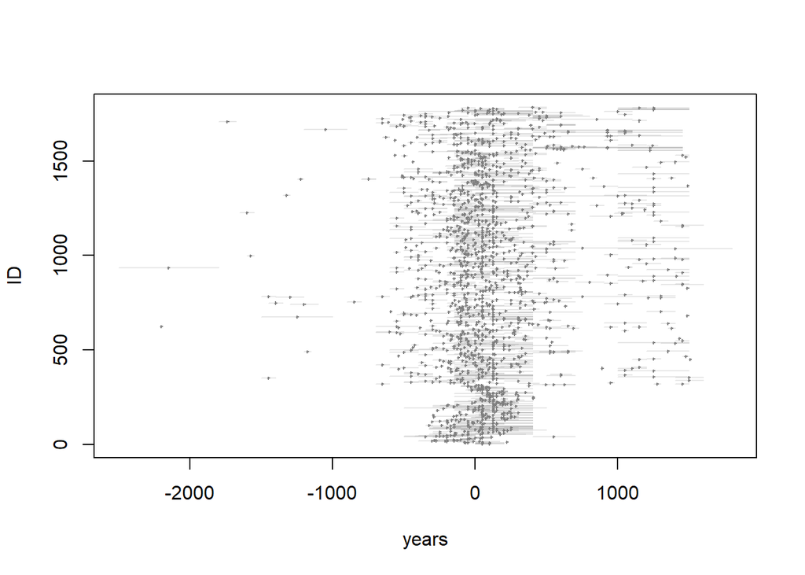

Mid Point of Date Range in Shipwrecks Data

### Aoristic Sum: Probability of existence of shipwrecks

There are different ways to estimate probabilities of existence of artefacts in the shipwrecks dataset.

For instance, the *aoristic sum* is a proxy to compute the probability of existence of archaeological artefacts such as shipwrecks. Below is the aoristic sum of the shipwrecks dataset that is computed by function `prex()` per century as specified in argument `'bins'` with the visualization afterwards as bar plots.

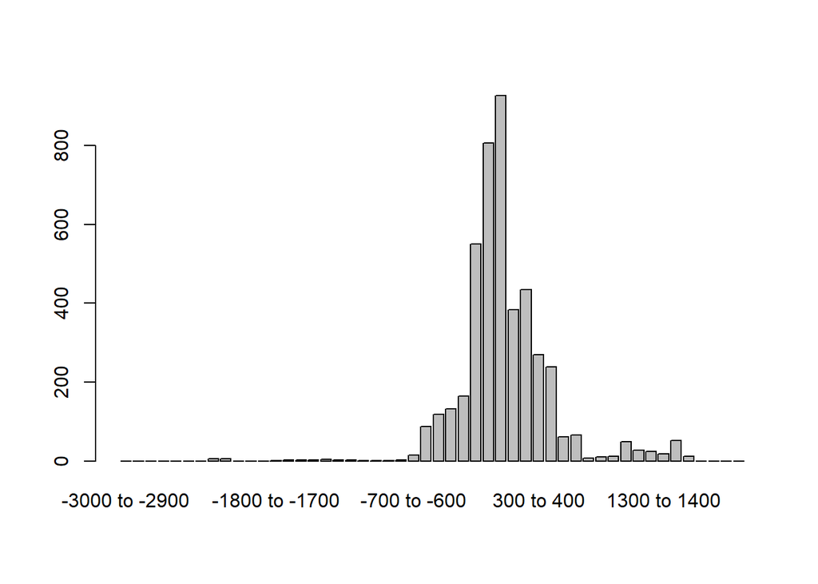

Aoristic Sum Shipwrecks Dataset (100 year bins)

```r
# plot aoristic sum per 100 years
require("magrittr")
sw %>%
  sdam::prex(vars=c("Earliest date", "Latest date"), bins=100) %>%
  barplot(main="Aoristic Sum Shipwrecks Dataset (100 year bins)")
```

There are in total 50 time blocks in the range of time of the shipwreck dataset; however, some shipwrecks may belong neither to the Hellenistic nor to the Roman period as we can see in the barplot. In order to delimitate the probability of existence results, we may need to look at a periodisation in history with chronological phases of the Mediterranean.

#### Distributions of Shipwrecks

Most of the shipwrecks in the database are from the Archaic to Middle Venetian, which is from 700 BC until AD 1600, and for the Byzantine period until AD 1200. According to the Mediterranean chronology phases, the Hellenistic and the Roman periods are from 325 BC to AD 650. If we consider the aoristic sum of shipwrecks from these later two periods, we end up with the following barplot.

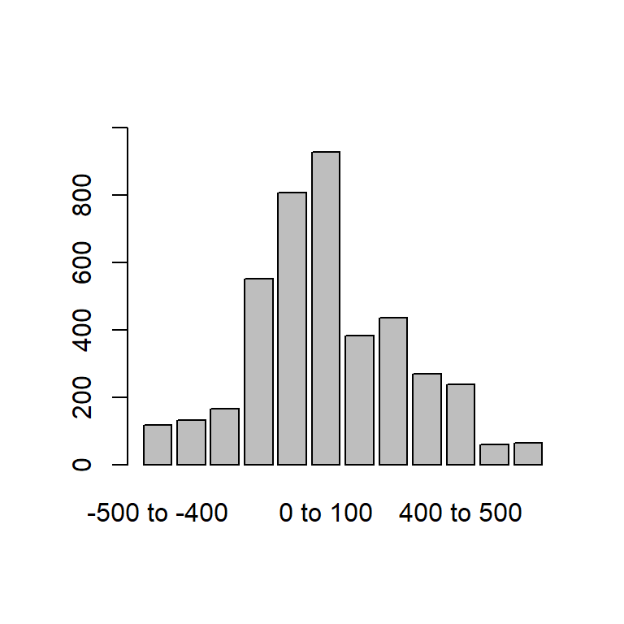

Aoristic Sum per Century for Hellenistic and Roman Periods

```r
# plot positions 26 to 37 in output for Hellenistic and Roman periods
require("magrittr")
sw %>%
prex(vars=c("Earliest date", "Latest date"), bins=100) %>%
  .[26:37] %>%
  barplot(ylim=c(0,1000))
```

The number of bins affects the shape of the distribution and, for instance, using 200 year `bins` the distribution has a relative stability stage from 200 BC to AD 200.

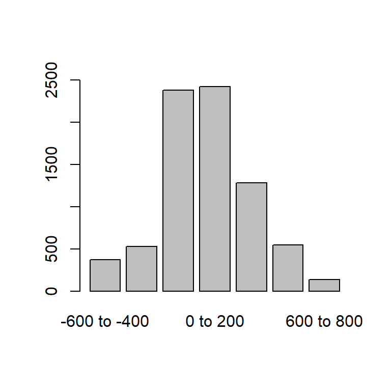

Aoristic Sum for Hellenistic and Roman Periods with 200 year `bins`.

```r
# Hellenistic and Roman periods now in positions 13 to 19
require("magrittr")
sw %>%
  prex(vars=c("Earliest date", "Latest date"), bins=200) %>%
  .[13:19] %>%
  barplot(ylim=c(0,2500))
```

#### Density estimate

Adding a kernel density (KD) estimate for a distribution requires the use of histograms for count data. Below there is an histogram of the distribution of shipwrecks together with a normal (or Gaussian) approximation curve and a kernel density line of the distribution.

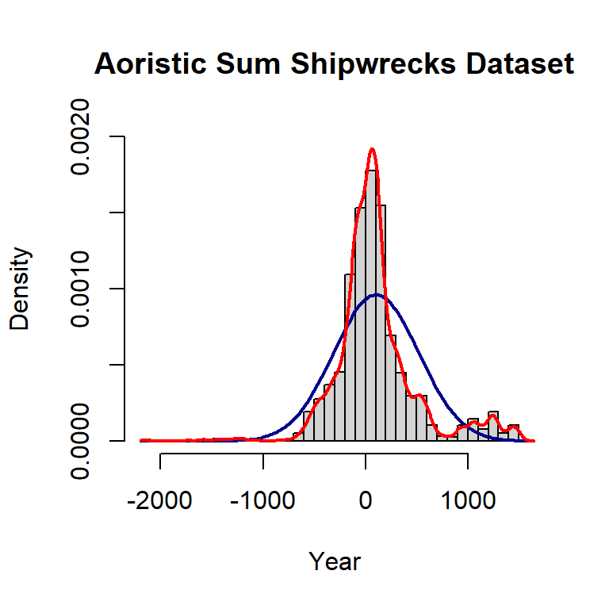

Aoristic Sum with normal kernel smooth.

#### Changing Resolution and Range

The aoristic sum is also calculated with different bins other than as per century. For instance, years from BC 600 to AD 400 are positions 97 to 136 in the aoristic sum range of shipwrecks in `sw` with bins to 25 years.

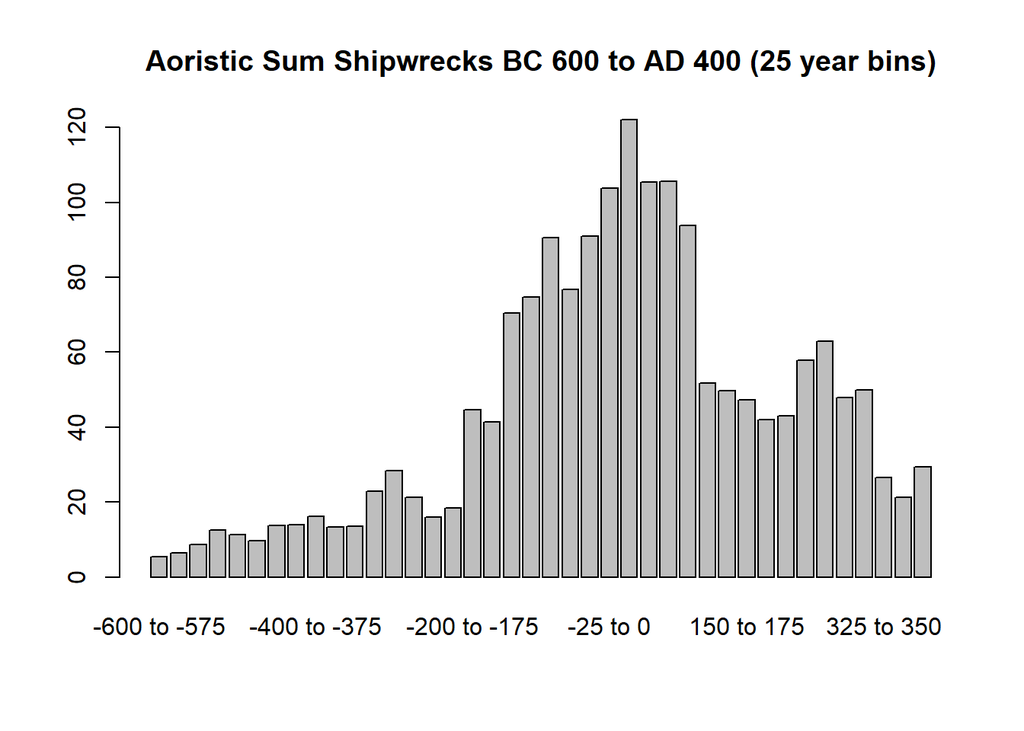

Aoristic Sum Shipwrecks BC 600 to AD 400 (25 year bins)

```r
# plot aoristic sum per 25 years
require("magrittr")
sw %>%
  sdam::prex(vars=c("Earliest date", "Latest date"), bins=25) %>%
  .[97:136] %>%
  barplot(main="Aoristic Sum Shipwrecks BC 600 to AD 400 (25 year bins)")
```

### Chronological Phases of the Mediterranean

Customized chronological phases of the Mediterranean are used for the analysis of Hellenistic and Roman shipwrecks. For instance, the chronological phases for dating ancient cultures of the Mediterranean Sea adapted from Bevan et al, 2013 are recorded in `cpmed` to compute the probability of existence.

```r
# Mediterranean chronology
load(file="cpmed.rda")
```

Look at the Mediterranean chronology phases and their length in years.

```r
# length of phases
summary(cpmed)
```

```
                                           Length Class  Mode
Middle to Late Neolithic (MN-LN)           1501   -none- numeric
Final Neolithic to Early Bronze 1 (FN-EB1) 1801   -none- numeric
Early Bronze 2 (EB2)                        501   -none- numeric
Late Prepalatial (LPrepal)                  301   -none- numeric
First Palace (FPal)                         201   -none- numeric
Second Palace (SPal)                        251   -none- numeric
Third Palace (TPal)                         251   -none- numeric
Post-Palatial to Protogeometric (PPalPg)    301   -none- numeric
Geometric (Geo)                             201   -none- numeric
Archaic (Arch)                              201   -none- numeric
Classical (Class)                           176   -none- numeric
Hellenistic (Hell)                          326   -none- numeric
Early Roman (ERom)                          201   -none- numeric
Middle Roman (MRom)                         151   -none- numeric
Late Roman (LRom)                           301   -none- numeric
Early Byzantine (EByz)                      251   -none- numeric
Middle Byzantine (MByz)                     301   -none- numeric
Early Venetian (EVen)                       201   -none- numeric
Middle Venetian (MVen)                      201   -none- numeric
Late Venetian (LVen)                        201   -none- numeric
```

Now we compute the aoristic sum as a proxy for the probability of existence of the shipwrecks using these chronological phases for the Mediterranean sea. Chronological phases are specified in argument `'cp'` of `prex()` where we can see that dating in `sw` extends from periods `Early Bronze 2` until `Late Venetian` according to Mediterranean chronology phases in `cpmed`.

```r
# aoristic sum with customize chronological phases
pcpmed <- prex(x=sw, vars=c("Earliest date", "Latest date"), cp=cpmed)
```

```
          Middle to Late Neolithic (MN-LN) Final Neolithic to Early Bronze 1 (FN-EB1)
                                  0.000000                                   0.000000
                      Early Bronze 2 (EB2)                 Late Prepalatial (LPrepal)
                                 25.765714                                  15.480000
                       First Palace (FPal)                       Second Palace (SPal)
                                  1.895143                                  15.060000
                       Third Palace (TPal)   Post-Palatial to Protogeometric (PPalPg)
                                 20.582000                                   9.130333
                           Geometric (Geo)                             Archaic (Arch)
                                  6.030000                                 202.518667
                         Classical (Class)                         Hellenistic (Hell)
                                312.064482                                4460.983147
                        Early Roman (ERom)                        Middle Roman (MRom)
                               2431.393379                                 881.868494
                         Late Roman (LRom)                     Early Byzantine (EByz)
                               1197.961713                                 101.507740
                   Middle Byzantine (MByz)                      Early Venetian (EVen)
                                226.294679                                  63.195987
                    Middle Venetian (MVen)                       Late Venetian (LVen)
                                124.057679                                   0.251250
```

Depicting the probability of existence using chronological phases in `pcpmed` as a barplot.

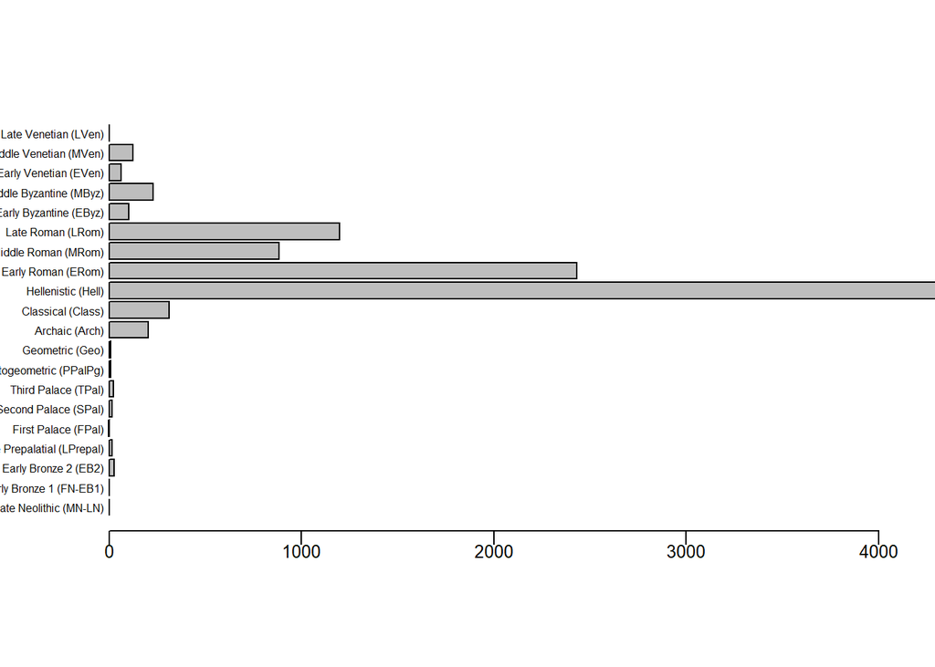

Aoristic Sum of Chronological Phases in the Mediterranean Sea.

```r
# horizontal barplot
require("magrittr")
pcpmed %>%
  barplot(horiz=TRUE, las=1, mgp=c(3,.2,0), cex.names=.5, cex.axis=.8, xlim=c(0,4000), xpd=TRUE)
```

## Shipwrecks by Century

Splitting the shipwrecks network into a specific century requires looking at the mid points of the timespans. .

The mid point of date range for each timespan and `"Date range"` is given by function `prex()` when the `'type'` argument is set to `mp`.

By looking at the tail of the output, we bear in mind that there are negative mid points, which correspond to periods before common era BC.

```r
# mid point and range
require("magrittr")
  prex(sw, type="mp", vars=c("Earliest date","Latest date")) %>%
  tail()
```

```
     Earliest date Latest date Mid point Range
1779            50         200     125.0   150
1780           400         500     450.0   100
1781          1000        1500    1250.0   500
1782          -100          -1     -50.5    99
1783          1100        1200    1150.0   100
1784           300         500     400.0   200
```

### Four centuries

To split the network into the first three common era centuries, we need take the mid points in `x` as median normalization values given by `prex()` as `Mid point`.

```r
# mid point dates in shipwrecks
tmp <- prex(sw, type="mp", vars=c("Earliest date","Latest date"))$`Mid point`
```

```r
# last mid points with negative dates and missing data
tail(tmp, 17)
```

```
 [1]     NA    0.0    0.0  -87.5  100.5 1250.0 1250.0  150.0 1250.0 1250.0   37.5  125.0  450.0
[14] 1250.0  -50.5 1150.0  400.0
```

Century time intervals of the shipwreck dataset with mid points are identified by Roman numerals with a character data type and they are recorded in `swmpc`.

```r
# 100 year bins until max value
require("magrittr")
swmpc <-
  findInterval(tmp, seq(0, max(tmp,na.rm=TRUE), by=100), all.inside=FALSE)  %>%
  utils::as.roman() %>%
  as.character()
```

By considering only common era years for centuries, all BC years with negative dates become `<NA>`. However, the not available entries in `swmpc` are a mixture of missing information and before common era years.

```r
# some records as centuries
require("magrittr")
swmpc[30:40] %>%
  noquote()
```

```
 [1] <NA> I    I    I    I    I    I    <NA> II   <NA> VI
```

To address this issue, assume first that all `<NA>`s are before common era or `"BC"`.

```r
# first all NAs are regarded as Before Common Era
swmpc[which(is.na(swmpc))] <- "BC"
```

```r
# the records without NAs
require("magrittr")
swmpc[30:40] %>%
  noquote()
```

```
 [1] BC I  I  I  I  I  I  BC II BC VI
```

Then we identify the missing information from `tmp` in `swmpc` with string `"NA"`.

```r
# missing data in 'tmp'
swmpc[which(is.na(tmp))] <- "NA"
```

```r
# records with the missing information
require("magrittr")
swmpc[30:40] %>%
  noquote()
```

```
 [1] BC I  I  I  I  I  I  BC II NA VI
```

Entries in the shipwrecks dataset with mid points as centuries for the first three centuries are

```r
# records of first three AD centuries
require("magrittr")
swmpc%in%c('I','II','III') %>%
  which() %>%
  head(10)
```

```
 [1]  1  2  3  4  5  6  7 10 11 13
```

Look at these records in the whole shipwrecks dataset in `sw`.

```r
#  shipwrecks for three centuries AD as tibble
sw[which(swmpc%in%c('I','II','III')), ]
```

```
# A tibble: 705 x 35
   `Wreck ID` `Strauss ID` Name    `Parker Number` `Sea area`   Country Region    Latitude Longitude
        <dbl>        <dbl> <chr>   <chr>           <chr>        <chr>   <chr>        <dbl>     <dbl>
 1          1          331 Komiza  <NA>            Adriatic     Croatia Vis Isla~     43.0      16.1
 2          2          328 Lokunji <NA>            Adriatic     Croatia Kvarner ~     44.7      14.3
 3          3          329 Mahara~ <NA>            Adriatic     Croatia Mljet is~     42.7      17.7
 4          4          330 Mlin    702             Adriatic     Croatia Split ch~     43.4      16.2
 5          5          322 Plavac~ 832             Adriatic     Croatia Zlarin I~     NA        NA
 6          6          326 Tramer~ <NA>            Adriatic     Croatia Northern~     44.2      14.8
 7          7          332 Veliki~ <NA>            Adriatic     Croatia Mljet is~     42.7      17.8
 8         10          323 Koroma~ <NA>            Adriatic     Croatia North si~     43.6      15.6
 9         11          372 Ognina~ 755             Central Med~ Italy   Near Syr~     NA        NA
10         13          337 Vele O~ <NA>            Adriatic     Croatia Near Los~     44.5      14.5
# ... with 695 more rows, and 26 more variables: Min depth <dbl>, Max depth <dbl>, Depth <chr>,
#   Period <chr>, Dating <chr>, Earliest date <dbl>, Latest date <dbl>, Date range <dbl>,
#   Mid point of date range <dbl>, Probability <dbl>, Place of origin <chr>,
#   Place of destination <chr>, Reference <chr>, Comments <chr>, Amphorae <lgl>, Marble <lgl>,
#   Columns etc <lgl>, Sarcophagi <lgl>, Blocks <lgl>, Marble type <chr>, Other cargo <chr>,
#   Hull remains <chr>, Shipboard paraphernalia <chr>, Ship equipment <chr>,
#   Estimated tonnage <dbl>, Amphora type <chr>
```

### Temporal Networks

Splitting of the network into centuries is by selecting information related to the ships cargo and its time blocks from the shipwrecks dataset.

```r
# variables of interes
vars <- c(1,20:21,24:28,15:16)
colnames(sw)[vars]
```

```
 [1] "Wreck ID"             "Place of origin"      "Place of destination" "Amphorae"
 [5] "Marble"               "Columns etc"          "Sarcophagi"           "Blocks"
 [9] "Earliest date"        "Latest date"
```

### *Saeculum I*

```r
# saeculum I
require("magrittr")
sw1 <- sw[which(swmpc%in%c('I')), vars] %>%
  cln(level=2, what=c("(",")"), case=1, na.rm=FALSE, repl=rptxt) %>%
  prex(vars=c("Earliest date", "Latest date"), type="mp", keep=TRUE)

head(sw1)
```

```
  Wreck ID Place of origin Place of destination Amphorae Marble Columns etc Sarcophagi Blocks
1        2             Cos       Northern Italy     TRUE  FALSE       FALSE      FALSE  FALSE
2        3          Rhodes       Northern Italy     TRUE  FALSE       FALSE      FALSE  FALSE
3        5            <NA>                 <NA>    FALSE  FALSE       FALSE      FALSE  FALSE
4        6          Rhodes       Northern Italy     TRUE  FALSE       FALSE      FALSE  FALSE
5       10          Aegean       Northern Italy     TRUE  FALSE       FALSE      FALSE  FALSE
6       13          Greece       Northern Italy    FALSE  FALSE       FALSE      FALSE  FALSE
  Earliest date Latest date Mid point Range
1             1         100      50.5    99
2             1         100      50.5    99
3             1         100      50.5    99
4             1         100      50.5    99
5             1         100      50.5    99
6          -110         170      30.0   280
```

```r
# matrix I from edge list
require("magrittr")
mtI <- sw1[,2:3] %>%
  transf(type="toarray", na.rm=FALSE)
```

```r
# number of destinations
dim(mtI)
```

```
[1] 49 49
```

### *Saeculum II*

```r
# saeculum II
require("magrittr")
sw2 <- sw[which(swmpc%in%c('II')), vars] %>%
  cln(level=2, what=c("(",")"), case=1, na.rm=FALSE, repl=rptxt) %>%
  prex(vars=c("Earliest date", "Latest date"), type="mp", keep=TRUE)

head(sw2)
```

```
  Wreck ID       Place of origin Place of destination Amphorae Marble Columns etc Sarcophagi Blocks
1        1                 Egypt       Northern Italy     TRUE  FALSE       FALSE      FALSE  FALSE
2        4                Aegean       Northern Italy     TRUE  FALSE       FALSE      FALSE  FALSE
3        7                Aegean       Northern Italy    FALSE   TRUE       FALSE       TRUE  FALSE
4       38 Thessaly, Proconnesus            Black Sea    FALSE   TRUE        TRUE      FALSE   TRUE
5       53              Carystos                Italy    FALSE   TRUE        TRUE      FALSE  FALSE
6       63                    NA                   NA     TRUE  FALSE       FALSE      FALSE  FALSE
  Earliest date Latest date Mid point Range
1             1         200     100.5   199
2             1         200     100.5   199
3             1         200     100.5   199
4           100         125     112.5    25
5             1         350     175.5   349
6           160         170     165.0    10
```

```r
# matrix II from edge list
require("magrittr")
mtII <- sw2[,2:3] %>%
  transf(type="toarray", na.rm=FALSE)
```

```r
# number of destinations
dim(mtII)
```

```
[1] 27 27
```

### *Saeculum III*

```r
# saeculum III
require("magrittr")
sw3 <- sw[which(swmpc%in%c('III')), vars] %>%
  cln(level=2, what=c("(",")"), case=1, na.rm=FALSE, repl=rptxt) %>%
  prex(vars=c("Earliest date", "Latest date"), type="mp", keep=TRUE)

head(sw3)
```

```
  Wreck ID            Place of origin Place of destination Amphorae Marble Columns etc Sarcophagi
1       11 Aegean/N. Africa/Propontis          Sicily/Rome     TRUE  FALSE       FALSE      FALSE
2       58                         NA                   NA     TRUE  FALSE       FALSE      FALSE
3       71                      Assos                Italy    FALSE   TRUE       FALSE       TRUE
4       73                     Aegean                Italy     TRUE   TRUE        TRUE      FALSE
5       75                     Aegean                 Rome     TRUE  FALSE       FALSE      FALSE
6       79                     Aegean         France/Spain    FALSE   TRUE       FALSE      FALSE
  Blocks Earliest date Latest date Mid point Range
1  FALSE           215         230     222.5    15
2  FALSE             1         400     200.5   399
3  FALSE           100         300     200.0   200
4  FALSE           200         250     225.0    50
5  FALSE          -100         500     200.0   600
6   TRUE           200         300     250.0   100
```

```r
# matrix I from edge list
require("magrittr")
mtIII <- sw3[,2:3] %>%
  transf(type="toarray", na.rm=FALSE)
```

```r
# number of destinations
dim(mtIII)
```

```
[1] 32 32
```

### Before Common Era

For years before common era or years BC, there is a special workflow for creating network data. Start by finding the positions of all `"BC"` mid point dates in `swmpc` to retrieve the BC years in the mid points previously recorded in `tmp`, and where `atmp` stands for the absolute values of the BC years.

```r
# how many BC dates?
require("magrittr")
which(swmpc%in%c('BC')) %>%
  length()
```

```
[1] 661
```

```r
# mid points BC years as absolute dates
require("magrittr")
atmp <-
  tmp[which(swmpc%in%c('BC'))] %>%
  abs()
```

```r
# last mid points of negative dates
tail(atmp)
```

```
[1]   2.5 350.0 187.5  50.5  87.5  50.5
```

`atmp` has any missing data.

Then record in `yearBC` all BC centuries as Roman numerals with absolute values.

```r
# use absolute value for BC
require("magrittr")
yearBC <-
  findInterval(atmp, seq(0, max(atmp,na.rm=TRUE), by=100), all.inside=FALSE) %>%
  utils::as.roman() %>%
  as.character()
```

```r
# look at some BC centuries
require("magrittr")
paste('-', yearBC, sep="") %>%
  head()
```

```
[1] "-I"   "-I"   "-I"   "-III" "-I"   "-II"
```

```r
# I BC
require("magrittr")
swBC <- sw[which(swmpc%in%c('BC')), vars] %>%
  cln(level=2, what=c("(",")"), case=1, na.rm=FALSE, repl=rptxt) %>%
  prex(vars=c("Earliest date", "Latest date"), type="mp", keep=TRUE) %>%
  .[which(yearBC%in%'I'),]

head(swBC)
```

```
   Wreck ID Place of origin Place of destination Amphorae Marble Columns etc Sarcophagi Blocks
1         8 Aegean Via Cosa               France     TRUE  FALSE       FALSE      FALSE  FALSE
2         9          Aegean                 Rome     TRUE  FALSE       FALSE      FALSE  FALSE
3        12     Proconnesus       Claros, Turkey     TRUE   TRUE        TRUE      FALSE   TRUE
5        15          Aegean                   NA    FALSE  FALSE       FALSE      FALSE  FALSE
16       26          Rhodes                   NA     TRUE  FALSE       FALSE      FALSE  FALSE
17       27             Cos                   NA     TRUE  FALSE       FALSE      FALSE  FALSE
   Earliest date Latest date Mid point Range
1            -80         -60     -70.0    20
2            -75         -25     -50.0    50
3           -125         -25     -75.0   100
5            -25          -1     -13.0    24
16          -100          -1     -50.5    99
17          -100          -1     -50.5    99
```

```r
# adjacency matrix I BC from edge list
require("magrittr")
mtIBC <- swBC[,2:3] %>%
  transf(type="toarray", na.rm=FALSE)
```

```r
# number of destinations BC I
dim(mtIBC)
```

```
[1] 36 36
```

### Plotting temporal networks

For the plotting of the shipwrecks dataset as temporal networks, create a scope for a valued graph with self-relationships and characteristics of nodes and edges.

```r
# scope temporal networks
scps <- list(valued=TRUE, loops=TRUE, cex=2, pos=0, col="#FFCC00", ecol="#AFDDE9",
             vcol0="white", fsize=7, hds=.5, vedist=-4)
```

Since many of the places in the shipwrecks dataset are undefined, the node in the valued graph representing missing information has a very wide self-edge, and the plotting of the graph requires loop scaling for a better visualization.

#### Saeculum I Ante

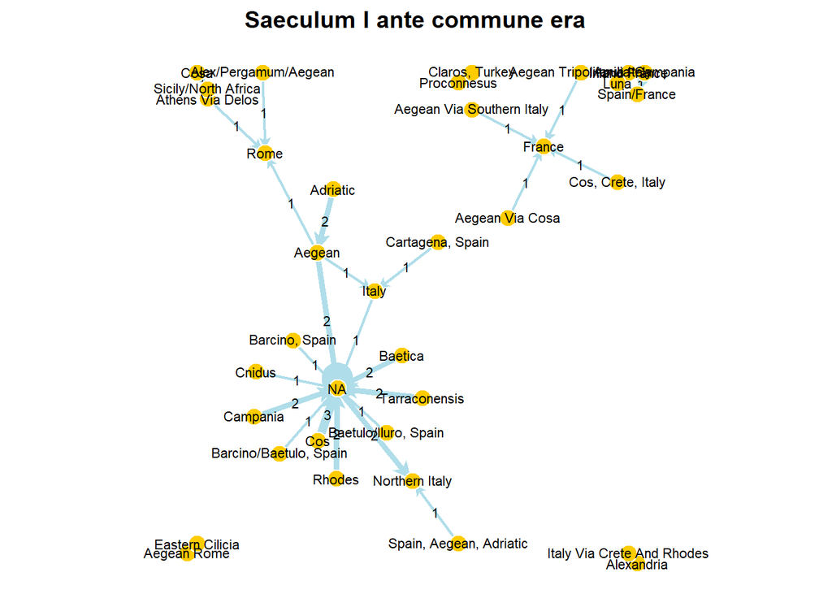

```r
# loop scale 10 pct
multigraph(mtIBC, scope=scps, values=TRUE, layout="force", seed=3, lscl=.1, main="Saeculum I ante commune era")
```

#### Saeculum I

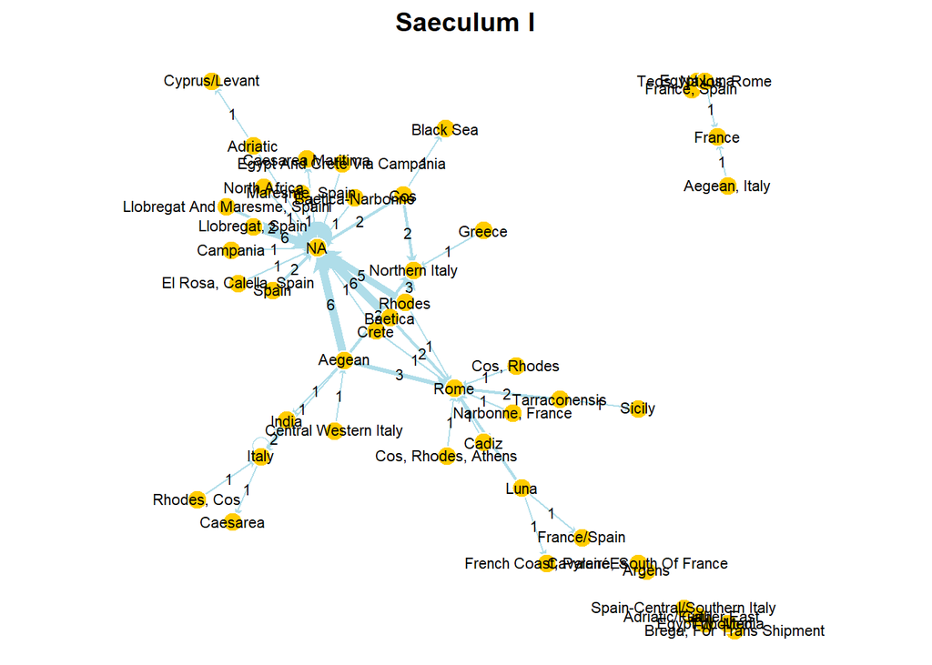

```r
# loop scale 5 pct
multigraph(mtI, scope=scps, values=TRUE, layout="force", seed=8, lscl=.05, main="Saeculum I")
```

#### Saeculum II

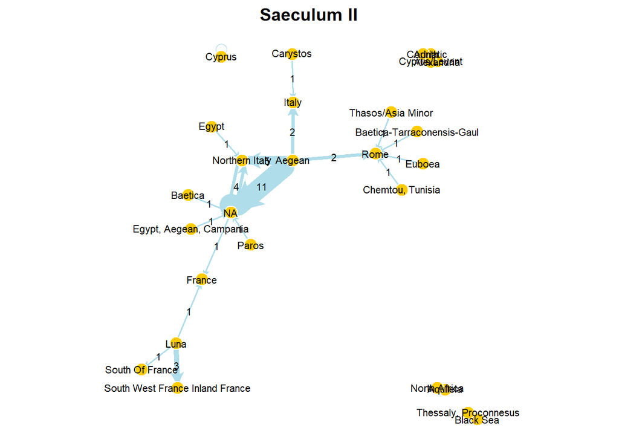

```r
# loop scale 10 pct
multigraph(mtII, scope=scps, values=TRUE, layout="force", seed=1, lscl=.1, main="Saeculum II")
```

#### Saeculum III

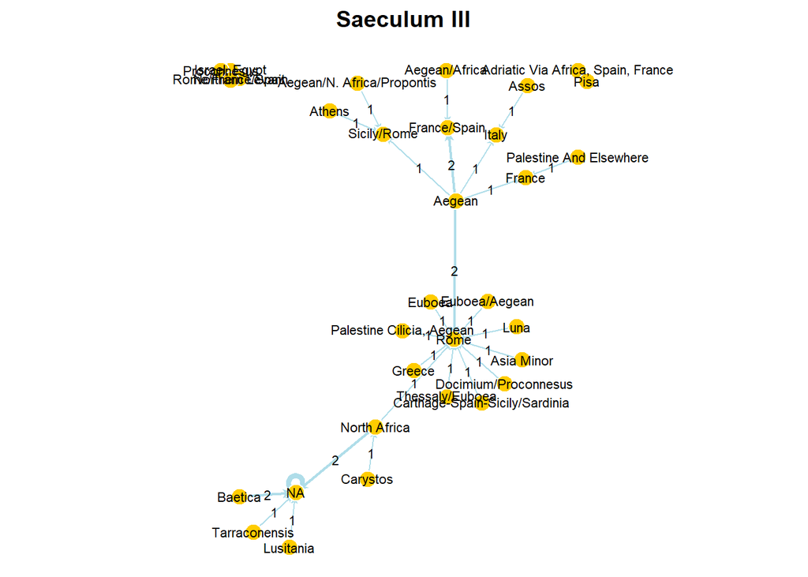

```r
# loop scale 5 pct
multigraph(mtIII, scope=scps, values=TRUE, layout="force", seed=5, lscl=.05, main="Saeculum III")
```

## Aggregation per Century

Recall from the Seas in the Mediterranean Basin section that `ss` records the code regions for seas in the Mediterranean, and  
this information is used for the aggregation of places when it comes to plot shipwrecks networks per century with a cartographical map.

```r
head(ss)
```

```
                               PLACE CODE
1                                      NA
2             A Palace In The Aegean    A
3                           Adriatic    D
4         Adriatic-Brindisi-Campania    D
5 Adriatic Via Africa, Spain, France    D
6              Adriatic/Further East    D
```

Similarly there is data frame `ssg` from section Aggregation of Sea Regions in the Mediterranean Basin, which binds the codes with regional groups.

```r
head(ssg)
```

```
   name group
1    NA     0
2     A     2
3     D     2
4 A,D,I     2
5   A,E     2
6 A,T,I    21
```

### Aggregation *Saeculum I ante*

For the first century BC, the adjacency matrix with regional maritime routes are obtained by matching edge lists with components `PLACE` and `CODE` in `ss` with origin and destination places in `swBC`. These two vectors are then binded with the cargo variables into the new data frame `swBCc` from which the aggregated adjacency matrix `matBCr` is created.

```r
# columns 2-8 for places origin/destination and cargo variables
swBCc <- cbind(swBC[,2:8], from=ss[match(swBC[,2], ss$PLACE),]$CODE,
                           to=ss[match(swBC[,3], ss$PLACE),]$CODE)
```

```r
head(swBCc)
```

```
   Place of origin Place of destination Amphorae Marble Columns etc Sarcophagi Blocks from  to
1  Aegean Via Cosa               France     TRUE  FALSE       FALSE      FALSE  FALSE    A L,G
2           Aegean                 Rome     TRUE  FALSE       FALSE      FALSE  FALSE    A   T
3      Proconnesus       Claros, Turkey     TRUE   TRUE        TRUE      FALSE   TRUE    A   A
5           Aegean                   NA    FALSE  FALSE       FALSE      FALSE  FALSE    A  NA
16          Rhodes                   NA     TRUE  FALSE       FALSE      FALSE  FALSE    A  NA
17             Cos                   NA     TRUE  FALSE       FALSE      FALSE  FALSE    A  NA
```

Match from `ssg`, which binds the names of the shipwreck places with their groups, in order to add to `swBCc` the regional groups in `swBCr` the origin and destination places as `fra` and `til` during the first century before common era.

```r
# I cent. BC regional groups
swBCr <- cbind(swBCc, fra=ssg[match(swBCc$from, ssg$name), ]$group,
                      til=ssg[match(swBCc$to, ssg$name), ]$group)
```

And we look at som `Place of origin` and `Place of destination` with their respective regional groups as `fra` and `til`.

```r
# last entries
tail(swBCr[,c(1:2,10:11)])
```

```
           Place of origin Place of destination  fra  til
635                   <NA>                 <NA> <NA> <NA>
638                   <NA>                 <NA> <NA> <NA>
656 Barcino/Baetulo, Spain                 <NA>    1 <NA>
659                   <NA>                 <NA> <NA> <NA>
660                   <NA>                 <NA> <NA> <NA>
661               Campania                 <NA>    1 <NA>
```

In case of plotting aggregated regions with the customized coordinaes `medcd` from above, however, make sure that all missing data is coded as `0`.

```r
# NAs as zero in from and to regional groups
swBCr$fra[is.na(swBCr$fra)] <- 0
swBCr$til[is.na(swBCr$til)] <- 0
```

In this case, there is any region `Out` during the first century before common era.

```r
# columns 10-11 are regional places
require("magrittr")
swBCr[,10:11] %>%
  transf(type="toarray", na.rm=FALSE)
```

```
     0 1 12 2 21
0  185 0  2 0  0
1    9 0  1 1  0
12   1 0  1 0  0
2    8 9  1 4  1
21   0 0  0 0  0
```

For plotting aggregated regions with the customized coordinates `medcd`, we need to add `3` so all regional groups are present in the matrix of relations.

```r
# adjacency matrix I BC with 'Out'
require("magrittr")
matBCr <-
  swBCr[,10:11] %>%
  transf(type="toarray", na.rm=FALSE, add="3")
```

[output not shown]

Now that the adjacency matrix `matBCr` for the shipwrecks routes during the first century BC has the five sea regions and `NA`.  
Then the plot of the graph with geography and customized labels

```r
# region 'out' is empty in I BC
lbs <- c("NA","West","West/East","East","East/West","")
```

Regional places in the shipwreck dataset allow plotting the network into the cartographical map of the Mediterranean basin with the customized coordinates in `medcd`.

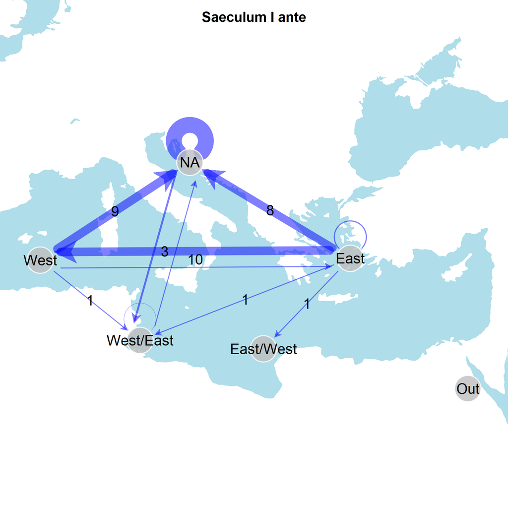

```r
# plot I BC with the customized coordinated system
sdam::plot.map(type="med", new=TRUE)
multigraph(matBCr, scope=scpv, loops=TRUE, values=TRUE, coord=medcd, lbs=lbs, lscl=.1, new=TRUE)
```

Similarly to the steps for the first century BC, centuries I, II, and III in the common era are:

### Aggregation *Saeculum I*

```r
# columns 2-8 for places origin/destination and cargo variables
sw1c <- cbind(sw1[,2:8], from=ss[match(sw1[,2], ss$PLACE),]$CODE,
                         to=ss[match(sw1[,3], ss$PLACE),]$CODE)
```

```r
# I cent. regional groups
sw1r <- cbind(sw1c, fra=ssg[match(sw1c$from, ssg$name), ]$group,
                    til=ssg[match(sw1c$to, ssg$name), ]$group)
```

```r
# I cent. NAs as zero regional groups
sw1r$fra[is.na(sw1r$fra)] <- 0
sw1r$til[is.na(sw1r$til)] <- 0
```

```r
# columns 10-11 are regional places
transf(sw1r[,10:11], type="toarray", na.rm=FALSE)
```

```
     0  1 12 2 21 3
0  244  0  0 1  0 0
1   20  8  0 1  1 0
12   0  0  1 2  0 2
2   18 13 10 2  0 1
21   0  1  0 0  0 0
3    0  0  0 0  0 0
```

In this case, there is no need to add any regional place.

```r
# adjacency matrix I BC with 'Out'
require("magrittr")
matIr <-
  sw1r[,10:11] %>%
  transf(type="toarray", na.rm=FALSE)
```

```r
# all regional groups in I cent.
lbs <- c("NA","West","West/East","East","East/West","Out")
```

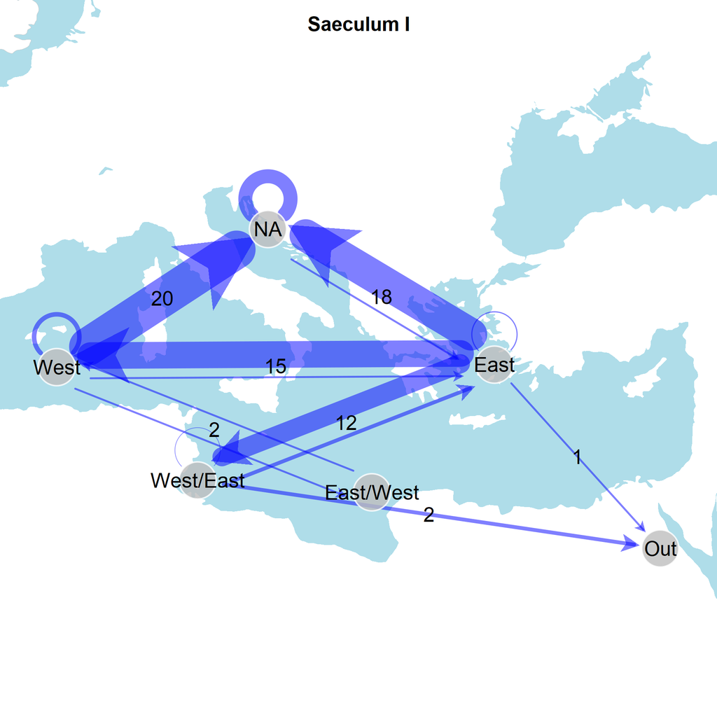

```r
# plot I with the customized coordinated system
sdam::plot.map(type="med", new=TRUE)
multigraph(matIr, scope=scpv, loops=TRUE, values=TRUE, coord=medcd, lbs=lbs, lscl=.1, new=TRUE)
```

### Aggregation *Saeculum II*

```r
# columns 2-8 for places origin/destination and cargo variables
sw2c <- cbind(sw2[,2:8], from=ss[match(sw2[,2], ss$PLACE),]$CODE,
                         to=ss[match(sw2[,3], ss$PLACE),]$CODE)
```

```r
# I cent. regional groups
sw2r <- cbind(sw2c, fra=ssg[match(sw2c$from, ssg$name), ]$group,
                    til=ssg[match(sw2c$to, ssg$name), ]$group)
```

```r
# II cent. NAs as zero regional groups
sw2r$fra[is.na(sw2r$fra)] <- 0
sw2r$til[is.na(sw2r$til)] <- 0
```

```r
# columns 10-11 are regional places
transf(sw2r[,10:11], type="toarray", na.rm=FALSE)
```

```
     0 1 12 2
0  221 1  2 0
1    1 2  0 0
12   2 0  0 0
2   13 9  9 5
```

For the second century, there is need to add regional groups `21` (East/West) and `3` (Out)

```r
# adjacency matrix II BC with 'East/West' and 'Out'
require("magrittr")
matIIr <-
  sw2r[,10:11] %>%
  transf(type="toarray", na.rm=FALSE, add=c("21","3"))
```

[output not shown]

```r
# regions 'East/West' and 'Out' are empty in II
lbs <- c("NA","West","West/East","East","","")
```

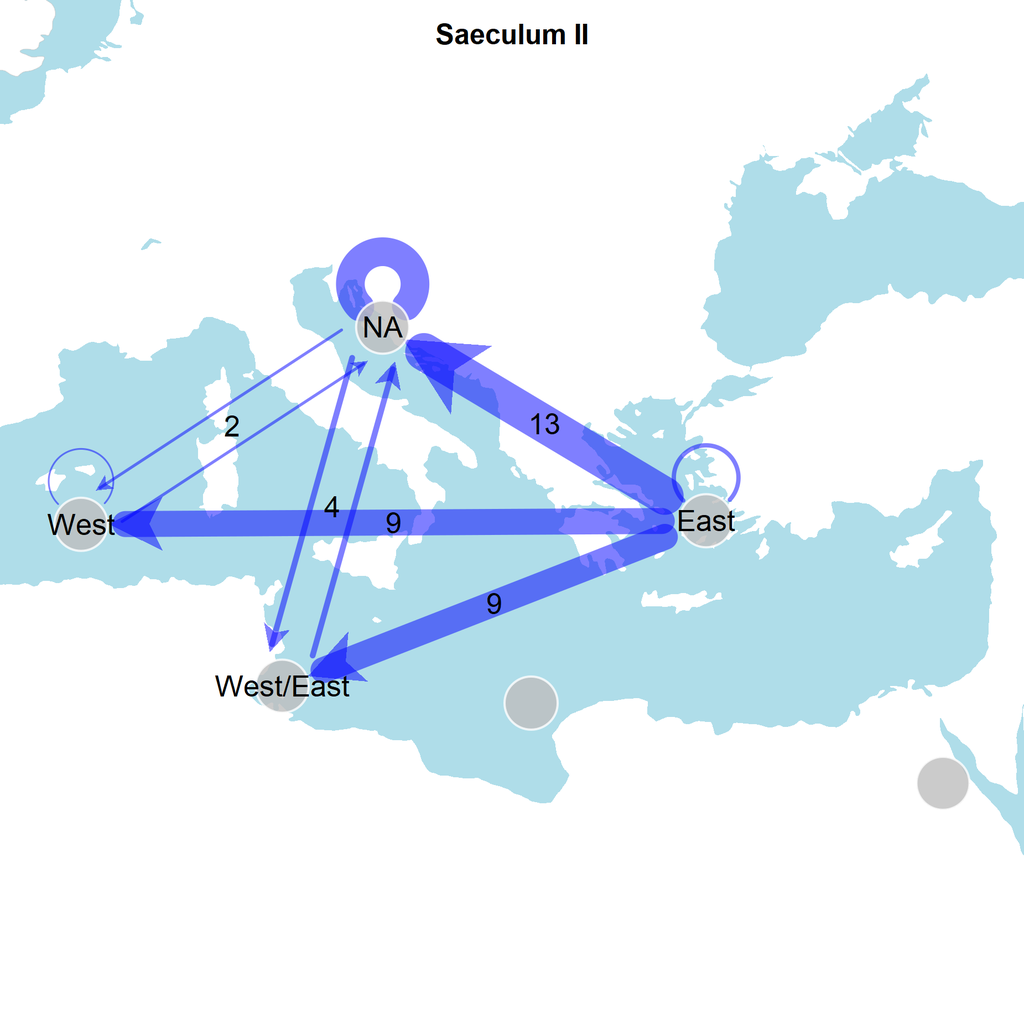

```r
# plot II with the customized coordinated system
sdam::plot.map(type="med", new=TRUE)
multigraph(matIIr, scope=scpv, loops=TRUE, values=TRUE, coord=medcd, lbs=lbs, lscl=.1, new=TRUE)
```

### Aggregation *Saeculum III*

```r
# columns 2-8 for places origin/destination and cargo variables
sw3c <- cbind(sw3[,2:8], from=ss[match(sw3[,2], ss$PLACE),]$CODE,
                         to=ss[match(sw3[,3], ss$PLACE),]$CODE)
```

```r
# I cent. regional groups
sw3r <- cbind(sw3c, fra=ssg[match(sw3c$from, ssg$name), ]$group,
                    til=ssg[match(sw3c$to, ssg$name), ]$group)
```

```r
# III cent. NAs as zero regional groups
sw3r$fra[is.na(sw3r$fra)] <- 0
sw3r$til[is.na(sw3r$til)] <- 0
```

```r
# columns 10-11 are regional places
transf(sw3r[,10:11], type="toarray", na.rm=FALSE)
```

```
    0  1 12 2 21
0  83  0  0 0  0
1   4  1  0 0  0
12  0  0  0 0  0
2   2 18  2 2  3
21  0  0  0 0  0
```

As with the first century BC, the thrid century does not have the `Out` regional group.

```r
# adjacency matrix III with 'Out'
require("magrittr")
matIIIr <-
  sw3r[,10:11] %>%
  transf(type="toarray", na.rm=FALSE, add="3")
```

[output not shown]

```r
# region 'out' is empty in III
lbs <- c("NA","West","West/East","East","East/West","")
```

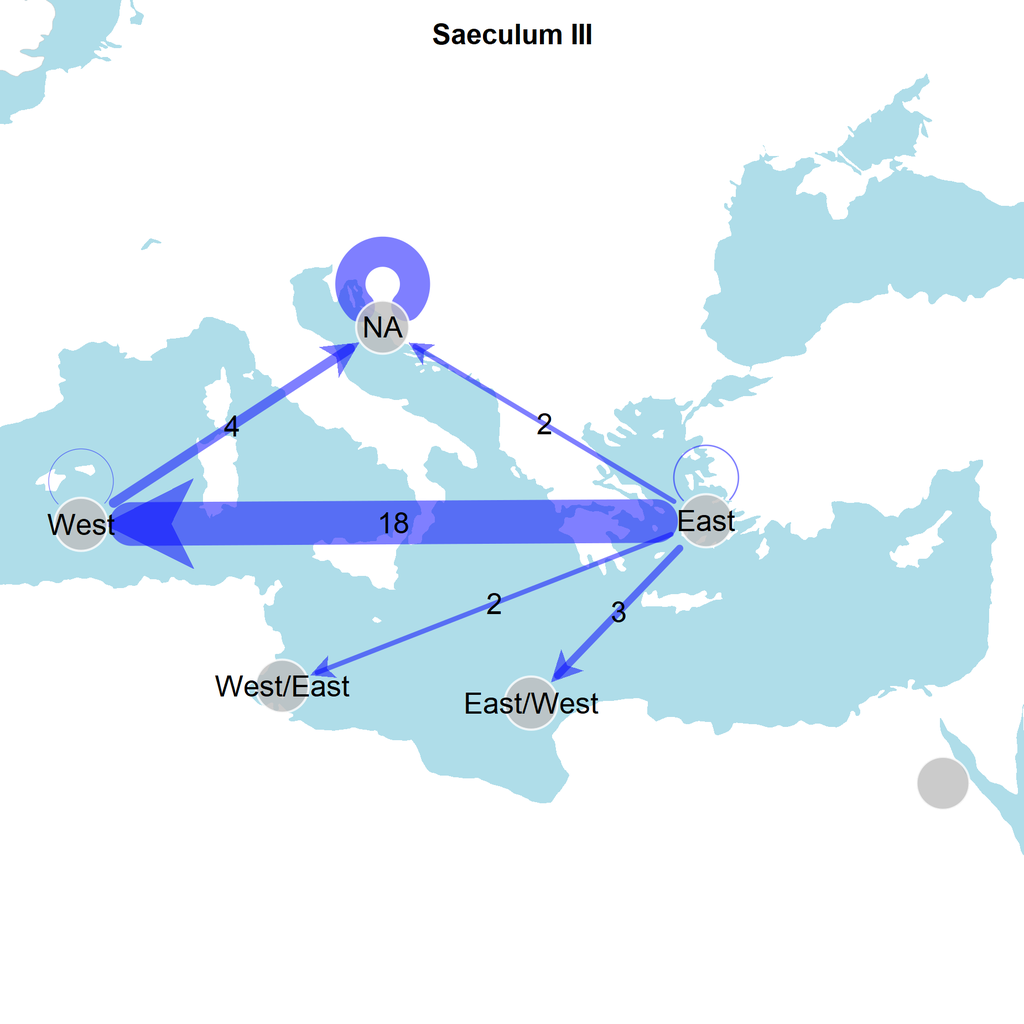

```r
# plot III with the customized coordinated system
sdam::plot.map(type="med", new=TRUE)
multigraph(matIIIr, scope=scpv, loops=TRUE, values=TRUE, coord=medcd, lbs=lbs, lscl=.1, new=TRUE)
```

### Animated plot

The graph with time and geography of the shipwrecks network with sea regions in the Mediterranean basin per four centuries

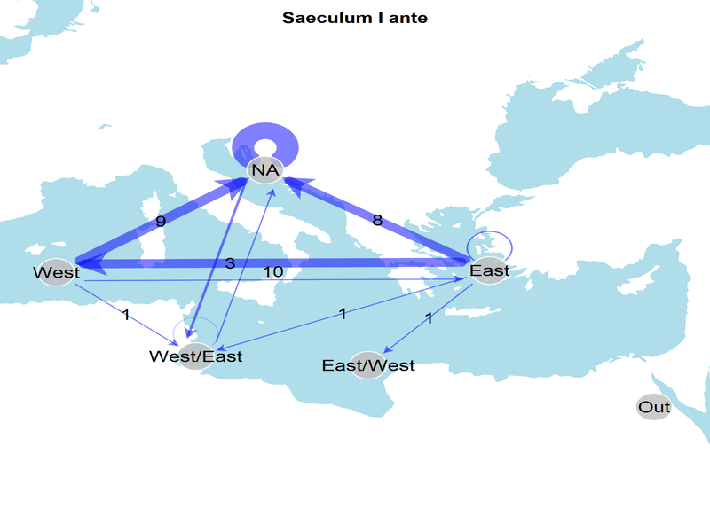

#### Cargoes in Shipwrecks

Summary of shipwrecks cargoes in the four centuries are in columns 4 to 8 of `sw0`, `sw1`, `sw2`, and `sw3`.

```r
# list of cargoes in data frames
require("magrittr")
list(I_BC=sw0[,4:8], I=sw1[,4:8], II=sw2[,4:8], III=sw3[,4:8]) %>%
  lapply(summary)
```

```
$I_BC
  Amphorae     Marble    Columns etc Sarcophagi    Blocks
 FALSE:142   FALSE:216   FALSE:219   FALSE:223   FALSE:220
 TRUE : 81   TRUE :  7   TRUE :  4               TRUE :  3

$I
  Amphorae     Marble    Columns etc Sarcophagi    Blocks
 FALSE:194   FALSE:312   FALSE:318   FALSE:325   FALSE:316
 TRUE :131   TRUE : 13   TRUE :  7               TRUE :  9

$II
  Amphorae     Marble    Columns etc Sarcophagi    Blocks
 FALSE:213   FALSE:241   FALSE:248   FALSE:261   FALSE:255
 TRUE : 52   TRUE : 24   TRUE : 17   TRUE :  4   TRUE : 10

$III
  Amphorae    Marble   Columns etc Sarcophagi    Blocks
 FALSE:77   FALSE:97   FALSE:103   FALSE:113   FALSE:106
 TRUE :38   TRUE :18   TRUE : 12   TRUE :  2   TRUE :  9
```

Most of the cargo found in the shipwrecks dataset is from the first century, while most of `Marble`, `Columns`, and `Blocks` in ships are from the second century. `Amphorae` peaks at the first century, then decline.

¨

## See Also

- [Centrality measures in ORBIS Roman transport network](https://htmlpreview.github.io/?https://github.com/sdam-au/R_code/blob/master/HTML/Centrality%20measures%20in%20ORBIS%20Roman%20transport%20network.html)
- [ORBIS Roman World transport network](https://htmlpreview.github.io/?https://github.com/sdam-au/R_code/blob/master/HTML/ORBIS%20Roman%20World%20transport%20network%20centrality%20measures.html)
- [Plotting Roman Empire transport network](https://sdam-au.github.io/sdam/articles/TransportNetwork.html)
- [Plotting ancient Roman provinces and regions](https://sdam-au.github.io/sdam/articles/RomanProvs.html)
- [Re-encoding Greek characters from ‘EDH’ dataset](https://sdam-au.github.io/sdam/articles/Encoding.html)
- [`"sdam"` manual](https://github.com/mplex/cedhar/blob/master/typesetting/reports/sdam.pdf)
- [Social Dynamics and complexity in the Ancient Mediterranean Project](https://sdam-au.github.io/sdam-au/)